# Transición Energética

2023-06-14

## Conntenido

- Objetivos
- 1.- Contexto global
- 2.- Problemática nacional
- 3.- Marco legal e institucional
- 4.- Desarrollo del problema
- 5.- Dilemas
- 6.- Soluciones
- Conclusiones
- Fuentes

## Objetivos

La transición energética se refiere al cambio del sector energético global de los sistemas de producción y consumo de energía basados en fósiles, incluidos el petróleo, el gas natural y el carbón, a fuentes de energía renovables como la eólica, la solar, hidrógeno, entre otras.

La creciente penetración de las energías renovables en la combinación de suministro de energía, la electrificación y las mejoras en el almacenamiento de energía son factores clave de la transición energética, por lo tanto, los objetivos de este trabajo son analizar la evolución al 2022, de los principales indicadores que nos permitan conocer si los objetivos se han alcanzado o si las tendencias son favorables, poniendo énfasis en el caso mexicano, además de identificar las causas y el papel del gobierno, comparado con otros países dentro del contexto latinoamericano.

## 1.- Contexto global del tema

De acuerdo con la NASA, en 2022 la temperatura promedio del planeta fue 0.89°C más caliente que la media de referencia de 1950-1980, alcanzando picos de 1.02°C en 2016 y 2020.

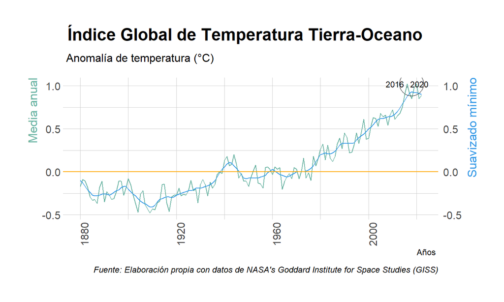

## 1.- Contexto global del tema

El calentamiento global, además de provocar el derretimiento de los casquetes polares y el aumento del nivel del mar, está provocando otros cambios climáticos como la desertificación y el aumento de fenómenos meteorológicos extremos como huracanes, inundaciones, incendios, entre otros.

## 1.- Contexto global del tema

La comunidad científica está de acuerdo en que esto se debe a las emisiones de gases de efecto invernadero a la atmósfera, especialmente desde la Revolución Industrial.

## 1.- Contexto global del tema

El principal gas de efecto invernadero, el dióxido de carbono, se origina en gran medida en el sector de la energía, principalmente la generación de electricidad.

## 1.- Contexto global del tema

En diciembre de 2015, en la COP 21 de París, se firmó un acuerdo internacional que fijó el objetivo de limitar el calentamiento global a finales de este siglo por debajo de los 2 °C en comparación con los niveles preindustriales y, preferentemente, limitarlo a 1.5 °C.

## 1.- Contexto global del tema

La COP26, que tuvo lugar en noviembre de 2021 en Glasgow, confirmó el compromiso de alcanzar la neutralidad de carbono para 2050.

## 1.- Contexto global del tema

Para lograr este objetivo, la principal herramienta es la transición energética, es decir, el cambio de una matriz energética basada en combustibles fósiles a uno que produzca emisiones de carbono muy limitadas, si no nulas, basado en fuentes de energía renovables.

## 1.- Contexto global del tema

Una gran contribución a la descarbonización proviene de la electrificación del consumo, reemplazando la electricidad generada a partir de combustibles fósiles por energía generada a partir de fuentes renovables, lo que también hace que otros sectores como el transporte sean más limpios; la digitalización de las redes también contribuye mejorando la eficiencia energética.

## 2.- Problemática nacional

## 3.- Marco legal e institucional

## 4.- Desarrollo del problema

## 5.- Dilemas

## 6.- Soluciones